# ANÁLISIS DE LA VIOLENCIA DE GÉNERO EN AMÉRICA LATINA Y EL CARIBE, ESPAÑA Y PORTUGAL: TENDENCIAS Y EVOLUCIÓN.

2023-07-21

Rebeca Goncalves, Iliana Dias, Daniel Valles y Carlos Landaeta.

### INTRODUCCIÓN.

El presente caso de estudio trata sobre la violencia contra las mujeres y adolescentes, ya sea por parte de sus parejas, un familiar o una persona ajena a ellas. Es un problema grave y extendido en todo el mundo. Se define como cualquier acto de violencia de género que resulte en daño físico o psicológico contra la mujer. Esta violencia puede tomar muchas formas diferentes, incluyendo el abuso físico, el acoso sexual, la explotación, la trata de personas y el feminicidio.

Según el informe de la Organización de las Naciones Unidas, ONU Mujeres (2017), las mujeres y adolescentes enfrentan acoso sexual y violencia en espacios públicos, transporte público, lugares de recreación y mercados, tanto en países en desarrollo como desarrollados. En Latinoamérica, se han establecido políticas públicas y programas para evaluar, monitorear y establecer medidas para prevenir y erradicar la violencia contra la mujer.

En los últimos años, ha habido numerosos casos en los que mujeres han sido víctimas de la violencia. Las historias de estas mujeres son impactantes y alarmantes, y deben ser atendidas con carácter prioritario y abordadas de manera efectiva por los gobiernos, organizaciones internacionales y la sociedad en su conjunto para garantizar y resguardar los derechos de las mujeres, niñas y adolescentes.

Mencionado lo anterior, la violencia de género es un tema importante y relevante en la sociedad actual. Por lo tanto, en este caso de estudio, nos enfocaremos en el análisis de la situación de violencia de género en América Latina y el Caribe, España y Portugal, específicamente tomando en cuenta la tendencia y evolución a lo largo de los años. Presentaremos gráficos que mostrarán las tasas de muertes de mujeres por razones de género en los países mencionados. Además, analizaremos cómo ha evolucionado la tasa de muertes de mujeres a lo largo del tiempo y si existe mejoría con respecto a la violencia de género en los países con legislaciones. Estos gráficos responderán a las interrogantes planteadas de los cuales se podrá sacar conclusiones.

### JUSTIFICACIÓN DEL TEMA ELEGIDO.

Se escogió el tópico de la violencia de género porque es un problema grave que afecta a millones de mujeres en las regiones que se estudiarán. La violencia de género es una violación de los derechos humanos y un problema de salud pública y justicia social. A pesar de los esfuerzos de los movimientos de las mujeres y la respuestas gubernamentales en muchos países, la violencia de género continúa afectando a millones de mujeres cada año. Es importante y fundamental analizar las tendencias y su evolución a lo largo de los años, así como si los países que tienen legislaciones al respecto han reducido la violencia de género. La disponibilidad de datos sobre la violencia contra las mujeres y adolescentes ha aumentado significativamente en los últimos años, lo que permite una mejor comprensión del problema y la identificación de estrategias para su prevención y erradicación.

Por otra parte, otro enfoque importante es la muerte de mujeres ocasionadas por su pareja o ex pareja íntima debido a la violencia, el cual también es un tema muy serio y que en parte ha sido abordado desde la perspectiva normativa, institucional y con políticas públicas específicas. A pesar de los progresos registrados en muchos lugares y de la lucha constante de las organizaciones por los derechos de las mujeres, la violencia hacia ellas sigue siendo altamente preocupante y persiste hasta hoy en día.

### INTERROGANTES A CONTESTAR.

Como ya mencionamos, se abordará el tópico de la violencia de género en diferentes países de América Latina, el Caribe, España y Portugal. Se analizarán sus tendencias y evolución a lo largo de los años, y algunas posibles correlaciones. Es por eso que se plantean las siguientes interrogantes:

**1.** ¿Cuál es la tasa de muertes de mujeres por razones de género en en los países estudiados?

**2.** ¿Cómo ha evolucionado la tasa de muertes de mujeres a lo largo del tiempo en estos países y cuáles son las posibles explicaciones para las tendencias observadas?

**3.** ¿Tienen los países con legislaciones en contra de la violencia de género mejorías al respecto?

#### SOBRE LOS DATOS.

**1.** DESCARGAS DE LIBRERÍAS EN CASO DE NO POSEER.

```r
#install.packages("readxl")
#install.packages("tidyverse")
#install.packages("tidyr")
#install.packages("cowplot")
#install.packages("xlsx")
#install.packages("ggplot2")
#install.packages("ggthemes")
#install.packages("countrycode")
#install.packages("rmarkdown")
```

**2.** LIBRERÍAS UTILIZADAS.

```r
library(readxl) # Leer archivos de excel
library(tidyverse) # Manejo de base de datos y gráficos
```

```r
library(tidyr)
library(cowplot) # Permite organizar fácilmente varios gráficos en una sola figura
library(xlsx) # Leer, escribir y formatear archivos de Excel
library(countrycode)
library(rmarkdown)
library(ggplot2)
```

**3.** DIRECTORIO.

```
## [1] "C:/Users/rebeca/source/repos/J/PF_Dias-Goncalves-Landaeta-Valles/IF"
```

**4.** CARGA DE DATOS Y FORMATO DE TABLAS.

```r
data <- read_excel("BaseDeDatosOriginal.xlsx")
data1 <- read_excel("TotalMuejeres.xlsx")
data2 <- read_excel("ProporcionQueNoDenuncian.xlsx")
data3 <- read_excel("Legislaciones.xlsx")
data4 <- read_excel("MuertesMujeres.xlsx")
data5 <- read_excel("LegislacionAbusoDomestico.xlsx")

# Aplica a la base de datos "data"
# Seleccionamos las columnas de interés y cambiamos el nombre a las columnas
data <- data %>% arrange(País__ESTANDAR, Años__ESTANDAR) %>% filter(Años__ESTANDAR >= 2000 & Años__ESTANDAR <= 2020) %>% select(País__ESTANDAR, Años__ESTANDAR, value, Tipodevalor) %>% rename(Value = value, Entity = País__ESTANDAR, Year = Años__ESTANDAR)

data$Year <- as.numeric(data$Year)

#Lista de Paises
country_list <- unique(data$Entity)

continentes <- tribble(
  ~pais,                    ~continente,
  "Costa Rica",               "Central America",
  "Trinidad y Tabago",      "South America",
  "San Vicente y las Granadinas", "South America",

  "Colombia", "South America",
  "España",  "Europe",
  "Granada",  "North America",

  "Jamaica", "North America",
  "Nicaragua", "North America",
  "Puerto Rico", "North America",

  "República Dominicana", "North America",
  "Santa Lucía",  "North America",
  "Suriname", "South America",

  "Dominica", "North America",
  "Saint Kitts y Nevis", "North America",
  "Islas Vírgenes Británicas", "North America",

  "Anguila", "North America",
  "Antigua y Barbuda",  "North America",
  "Guyana", "South America",

  "Montserrat", "North America",
  "Chile",  "South America",
  "Paraguay", "South America",

  "Uruguay", "South America",
  "Perú",  "South America",
  "Honduras", "North America",

  "Barbados", "North America",
  "Belice", "North America",
  "El Salvador", "North America",

  "Argentina", "South America",
  "Venezuela (República Bolivariana de)", "South America",
  "Ecuador", "South America",
  "Portugal", "Europe",
  "Cuba",  "North America",
  "Panamá", "Central America")

# asignar continentes a la base de datos data
data <- data %>% mutate(continente = ifelse(Entity %in% continentes$pais,
                                              yes= continentes$continente[match(Entity, continentes$pais)],
                                              no= NA))
# Aplica a la base de datos "data1"
# Código para ordenar por paises y por año. Además para filtrar los no continentes y por los años de interés
data1 <- data1 %>% arrange(Entity, Year) %>%
  filter(Entity != "Channel Islands" & Entity != "East Asia and Pacific" &
         Entity != "Europe and Central Asia" & Entity != " European Union" &
         Entity != "World" & Entity !="High income" &
         Entity != "Latin America and Caribbean" & Entity != "Low and middle income"  &
         Entity != "Lower middle income" & Entity !="High income" &
         Entity != "Micronesia (country)" &  Entity!="Middle East and North Africa" &
         Entity != "Middle income" &  Entity != "North America" &
         Entity != "South Asia" &  Entity!= "Sub-Saharan Africa"& Entity  !="Upper middle income"  &
         Entity != "Aruba" & Entity != "Curacao" & Entity != "European Union" &
         Entity != "French Polynesia" & Entity != "Guam" & Entity != "Hong Kong" &
         Entity != "Low income" & Entity != "Macao" &
         Entity != "New Caledonia"  & Entity != "Palestine" &
         Entity != "United States Virgin Islands" & Entity != "Low income" & Entity != "Puerto Rico" & Entity != "Virgin Islands (U.S.)",
         Year >= 2000 & Year <= 2020)

# Añade una nueva columna con los países en español
data1$Entity_es <- countrycode(data1$Entity, "country.name.en", "un.name.es")

# Seleccionamos las columnas de interés y cambiamos el nombre a las columnas
data1 <- data1 %>% select(Entity_es, Code, Year, Population) %>% rename(Entity = Entity_es)

# Aplica a la base de datos "data2"
# Código para ordenar por paises y por año. Además para filtrar los no continentes y por los años de interés
data2 <- data2 %>% arrange(CountryName, Year) %>%
              filter(CountryName != "East Asia & Pacific" & CountryName != "Europe & Central Asia" &
                     CountryName != "Hong Kong SAR, China" &   CountryName != "High income" &
                     CountryName != "Latin America & Caribbean" &
                     CountryName != "Low income"  & CountryName !="Lower middle income" &
                     CountryName != "Middle East & North Africa" & CountryName != "North America" &
                     CountryName != "South Asia" &  CountryName!= "Sub-Saharan Africa" &
                     CountryName  !="Upper middle income" &
                     CountryName != "West Bank and Gaza" & CountryName != "Kosovo" & CountryName != "New Caledonia" & CountryName != "Virgin Islands (U.S.)", Year >= 2014 & Year <= 2020)

# Añade una nueva columna con los países en español
data2$Entity_es <- countrycode(data2$CountryName, "country.name.en", "un.name.es")

# Seleccionamos las columnas de interés y cambiamos el nombre a las columnas
data2 <- data2 %>% select(Entity_es, CountryCode, Year, Value) %>% rename(Entity = Entity_es, Code = CountryCode, NotReport = Value)

# Aplica a la base de datos "data3"
# Añade una nueva columna con los países en español
data3$Entity_es <- countrycode(data3$CountryName, "country.name.en", "un.name.es")

# Seleccionamos las columnas de interés y cambiamos el nombre a las columnas
data3 <- data3 %>% arrange(Entity_es, Year) %>% select(Entity_es, CountryCode, Year, Value) %>% rename(Entity = Entity_es, Code = CountryCode, Legislation= Value)

# Aplica a la base de datos "data4"
# Código para ordenar por paises y por año. Además para filtrar los no continentes y por los años de interés
data4 <- data4 %>% arrange(CountryName, Year) %>%
  filter(CountryName != "Africa Eastern and Southern" & CountryName != "Africa Western and Central" &
         CountryName != "American Samoa" &   CountryName != "Arab World" &
         CountryName != "Aruba" & CountryName != "Bermuda"  & CountryName !="Caribbean small states" &
         CountryName != "Cayman Islands" & CountryName != "Central Europe and the Baltics" &
         CountryName != "EAR" &  CountryName!= "East Asia & Pacific (IDA & IBRD)" &
         CountryName != "Euro area" & CountryName != "Europe & Central Asia (excluding high income)" &
         CountryName != "Europe & Central Asia"& CountryName != "Europe & Central Asia (IDA & IBRD)" &
         CountryName != "European Union" & CountryName != "Fragile and conflict affected situations" &
         CountryName != "French Polynesia" & CountryName != "Gibraltar" &
         CountryName != "Greenland"  & CountryName !="Guam" &
         CountryName != "Heavily indebted poor countries (HIPC)" & CountryName != "High income" &
         CountryName != "Curacao" &  CountryName!= "East Asia & Pacific" &
         CountryName  !="East Asia & Pacific (excluding high income)" &
         CountryName != "British Virgin Islands" & CountryName != "Channel Islands" &
         CountryName != "Hong Kong SAR, China" & CountryName != "IBRD only " &
         CountryName != "IDA & IBRD total" & CountryName != "IDA blend" &
         CountryName != "IDA only" & CountryName != "Isle of Man" & CountryName != "Kosovo" &
         CountryName != "Latin America & Caribbean" &
         CountryName != "Latin America & Caribbean (excluding high income)" &
         CountryName != "Latin America & Caribbean (IDA & IBRD)" &
         CountryName != "Least developed countries: UN classification" &
         CountryName != "LMY" & CountryName != "Low income" & CountryName != "Lower middle income" &
         CountryName != "LTE" &  CountryName != "Macao SAR, China" & CountryName != "IBRD only" &
         CountryName != "MIC" &  CountryName != "Middle East & North Africa"  &
         CountryName != "IDA total" & CountryName != "Middle East & North Africa (excluding high income)" &
         CountryName != "Middle East & North Africa (IDA & IBRD)"  &  CountryName != "OECD members" &
         CountryName != "Other small states" &  CountryName != "Pacific island small states"  &
         CountryName != "PRE" & CountryName != "PST" &  CountryName != "Small states"  &
         CountryName != "South Asia (IDA & IBRD)" & CountryName != "St. Martin (French part)" &
         CountryName != "Sub-Saharan Africa (excluding high income)"  &
         CountryName != "Sub-Saharan Africa (IDA & IBRD)" &
         CountryName != "Turks and Caicos Islands" &  CountryName != "West Bank and Gaza" & CountryName != "World" &
         CountryName != "North America" & CountryName != "South Asia" & CountryName != "Sub-Saharan Africa" &
         CountryName != "Upper middle income" & CountryName != "Puerto Rico" & CountryName != "New Caledonia" & CountryName != "Virgin Islands (U.S.)",
         Year >= 2000 & Year <= 2020, `Indicator Name` == "Intentional homicides, female (per 100,000 female)")
```

```r
# Añade una nueva columna con los países en español
data4$Entity_es <- countrycode(data4$CountryName, "country.name.en", "un.name.es")

# Seleccionamos las columnas de interés y cambiamos el nombre a las columnas
data4 <- data4 %>% select(Entity_es, CountryCode, Year, Value) %>% rename(Entity = Entity_es, Code = CountryCode, Death = Value)

# Aplica a la base de datos "data5"
# Código para ordenar por paises y por año.
data5 <- data5 %>%
  pivot_longer(cols = `2000 [YR2000]`:`2020 [YR2020]`, names_to = "Year", values_to = "Value") %>%
  select(`Country Name`, `Country Code`, Year, Value) %>%
  rename(Entity = `Country Name`, Code = `Country Code`, HasLegislationDomesticViolence = Value) %>%
  arrange(Entity, Year) %>%
  filter(Entity != "Africa Eastern and Southern" & Entity != "Africa Western and Central" &
           Entity != "American Samoa" &   Entity != "Arab World" &
           Entity != "Aruba" & Entity != "Bermuda"  & Entity !="Caribbean small states" &
           Entity != "Cayman Islands" & Entity != "Central Europe and the Baltics" &
           Entity != "EAR" &  Entity!= "East Asia & Pacific (IDA & IBRD)" &
           Entity != "Euro area" & Entity != "Europe & Central Asia (excluding high income)" &
           Entity != "Europe & Central Asia"& Entity != "Europe & Central Asia (IDA & IBRD)" &
           Entity != "European Union" & Entity != "Fragile and conflict affected situations" &
           Entity != "French Polynesia" & Entity != "Gibraltar" &
           Entity != "Greenland"  & Entity !="Guam" &
           Entity != "Heavily indebted poor countries (HIPC)" & Entity != "High income" &
           Entity != "Curacao" &  Entity!= "East Asia & Pacific" &
           Entity  !="East Asia & Pacific (excluding high income)" &
           Entity != "British Virgin Islands" & Entity != "Channel Islands" &
           Entity != "Hong Kong SAR, China" & Entity != "IBRD only " &
           Entity != "IDA & IBRD total" & Entity != "IDA blend" &
           Entity != "IDA only" & Entity != "Isle of Man" & Entity != "Kosovo" &
           Entity != "Latin America & Caribbean" &
           Entity != "Latin America & Caribbean (excluding high income)" &
           Entity != "Latin America & Caribbean (IDA & IBRD)" &
           Entity != "Least developed countries: UN classification" &
           Entity != "LMY" & Entity != "Low income" & Entity != "Lower middle income" &
           Entity != "LTE" &  Entity != "Macao SAR, China" & Entity != "IBRD only" &
           Entity != "MIC" &  Entity != "Middle East & North Africa"  &
           Entity != "IDA total" & Entity != "Middle East & North Africa (excluding high income)" &
           Entity != "Middle East & North Africa (IDA & IBRD)"  &  Entity != "OECD members" &
           Entity != "Other small states" &  Entity != "Pacific island small states"  &
           Entity != "PRE" & Entity != "PST" &  Entity != "Small states"  &
           Entity != "South Asia (IDA & IBRD)" & Entity != "St. Martin (French part)" &
           Entity != "Sub-Saharan Africa (excluding high income)"  &
           Entity != "Sub-Saharan Africa (IDA & IBRD)" &
           Entity != "Turks and Caicos Islands" &  Entity != "West Bank and Gaza" & Entity != "World" &
           Entity != "North America" & Entity != "South Asia" & Entity != "Sub-Saharan Africa" &
           Entity != "Upper middle income" & Entity != "Puerto Rico" &
           Entity != "Early-demographic dividend" & Entity != "Faroe Islands" &
           Entity != "Late-demographic dividend" & Entity != "Low & middle income" &
           Entity != "Middle income" & Entity != "New Caledonia" &
           Entity != "Northern Mariana Islands" & Entity != "Post-demographic dividend" &
           Entity != "Pre-demographic dividend" & Entity != "Sint Maarten (Dutch part)" &
           Entity != "Virgin Islands (U.S.)")

#Formato de años
data5$Year <- as.numeric(gsub("\\[.*\\]", "", data5$Year))

#Traduccion de nombres de paises
data5$Entity_es <- countrycode(data5$Entity, "country.name.en", "un.name.es")
data5 <- data5 %>%
  select(Entity_es, Code, Year, HasLegislationDomesticViolence) %>%
  rename(Entity = Entity_es)

#FILTRAR PARA OBTENER PAISES ESTABLECIDOS --------------------------------------

data1 <- data1 %>%
  filter(Entity %in% country_list)

data2 <- data2 %>%
  filter(Entity %in% country_list)

data3 <- data3 %>%
  filter(Entity %in% country_list)

data4 <- data4 %>%
  filter(Entity %in% country_list)

data5 <- data5 %>%
  filter(Entity %in% country_list)

colors_vec <- c("#4d4dff", "#00b3b3", "#00cc99", "#b3b300", "#b35900", "#cc99cc", "#ff4d4d", "#808080", "#ff9933", "#6666ff", "#00e6e6", "#b3b3b3", "#ff66ff", "#ffcc99", "#99ff99", "#ff6666", "#b3b300", "#00b3b3", "#ff99cc", "#6666ff", "#ffcc00", "#cc00cc", "#ff4d4d", "#00cc00", "#b35900", "#4d4dff", "#808080", "#FF9933", "#99E6E6", "#FF99CC", "#6666FF", "#FFCC70", "#CC00CC")
names(colors_vec) <- c("Costa Rica", "Trinidad y Tabago", "San Vicente y las Granadinas", "Colombia", "España", "Granada", "Jamaica", "Nicaragua", "Puerto Rico", "República Dominicana", "Santa Lucía", "Suriname", "Dominica", "Saint Kitts y Nevis", "Islas Vírgenes Británicas", "Anguila", "Antigua y Barbuda", "Guyana", "Montserrat", "Chile", "Paraguay", "Uruguay", "Perú", "Honduras", "Barbados", "Belice", "El Salvador", "Argentina", "Venezuela (República Bolivariana de)", "Ecuador", "Portugal", "Cuba", "Panamá")
```

**3.** VISUALIZACIÓN DEL ENCABEZADO DE LAS BASES DE DATOS

```r
# Aplica para la base de datos data
# Visualizar las 10 primeras datas
paged_table(
  data)
```

| Entity | Year | Value | Tipodevalor | continente |
| --- | --- | --- | --- | --- |
| Anguila | 2005 | 0.0000000 | Número absoluto | North America |
| Anguila | 2006 | 0.0000000 | Número absoluto | North America |
| Anguila | 2007 | 1.0000000 | Número absoluto | North America |
| Anguila | 2008 | 0.0000000 | Número absoluto | North America |
| Anguila | 2009 | 0.0000000 | Número absoluto | North America |
| Anguila | 2010 | 0.0000000 | Número absoluto | North America |
| Anguila | 2011 | 0.0000000 | Número absoluto | North America |
| Anguila | 2012 | 0.0000000 | Número absoluto | North America |
| Anguila | 2013 | 0.0000000 | Número absoluto | North America |
| Anguila | 2014 | 0.0000000 | Número absoluto | North America |

[output cut: 761 more lines]

```r
# Aplica para la base de datos data1
paged_table(
  data1)
```

| Entity | Code | Year | Population |
| --- | --- | --- | --- |
| Antigua y Barbuda | ATG | 2000 | 53.01749 |
| Antigua y Barbuda | ATG | 2001 | 53.00212 |
| Antigua y Barbuda | ATG | 2002 | 52.93111 |
| Antigua y Barbuda | ATG | 2003 | 52.81235 |
| Antigua y Barbuda | ATG | 2004 | 52.69394 |
| Antigua y Barbuda | ATG | 2005 | 52.57912 |
| Antigua y Barbuda | ATG | 2006 | 52.47053 |
| Antigua y Barbuda | ATG | 2007 | 52.37716 |
| Antigua y Barbuda | ATG | 2008 | 52.30227 |
| Antigua y Barbuda | ATG | 2009 | 52.22208 |

[output cut: 557 more lines]

```r
# Aplica para la base de datos data2
paged_table(
  data2)
```

| Entity | Code | Year | NotReport |
| --- | --- | --- | --- |
| Argentina | ARG | 2018 | 27.00000 |
| Argentina | ARG | 2018 | 29.84517 |
| Belice | BLZ | 2018 | 24.00000 |
| Belice | BLZ | 2018 | 23.90261 |
| Chile | CHL | 2018 | 21.00000 |
| Chile | CHL | 2018 | 21.38311 |
| Colombia | COL | 2018 | 30.00000 |
| Colombia | COL | 2018 | 31.12541 |
| Costa Rica | CRI | 2018 | 27.00000 |
| Costa Rica | CRI | 2018 | 27.78814 |

[output cut: 36 more lines]

```r
# Aplica para la base de datos data3
paged_table(
  data3)
```

| Entity | Code | Year | Legislation |
| --- | --- | --- | --- |
| Colombia | COL | 2010 | 79.1 |
| Colombia | COL | 2010 | 60.5 |
| Colombia | COL | 2010 | 75.4 |
| Colombia | COL | 2010 | 82.2 |
| Colombia | COL | 2010 | 85.0 |
| Colombia | COL | 2010 | 87.8 |
| Colombia | COL | 2010 | 80.5 |
| Colombia | COL | 2010 | 62.0 |
| Colombia | COL | 2010 | 77.1 |
| Colombia | COL | 2010 | 83.5 |

[output cut: 434 more lines]

```r
# Aplica para la base de datos data4
paged_table(
  data4)
```

| Entity | Code | Year | Death |
| --- | --- | --- | --- |
| Antigua y Barbuda | ATG | 2001 | 1.9259791 |
| Antigua y Barbuda | ATG | 2002 | 3.0566831 |
| Antigua y Barbuda | ATG | 2008 | 11.3938040 |
| Antigua y Barbuda | ATG | 2015 | 2.1237059 |
| Antigua y Barbuda | ATG | 2016 | 4.2204778 |
| Antigua y Barbuda | ATG | 2017 | 4.1965232 |
| Antigua y Barbuda | ATG | 2018 | 6.2617408 |
| Antigua y Barbuda | ATG | 2019 | 2.0766060 |
| Antigua y Barbuda | ATG | 2020 | 2.0648998 |
| Argentina | ARG | 2015 | 1.7707825 |

[output cut: 436 more lines]

```r
# Aplica para la base de datos data4
paged_table(
  data5)
```

| Entity | Code | Year | HasLegislationDomesticViolence |
| --- | --- | --- | --- |
| Antigua y Barbuda | ATG | 2000 | 1 |
| Antigua y Barbuda | ATG | 2001 | 1 |
| Antigua y Barbuda | ATG | 2002 | 1 |
| Antigua y Barbuda | ATG | 2003 | 1 |
| Antigua y Barbuda | ATG | 2004 | 1 |
| Antigua y Barbuda | ATG | 2005 | 1 |
| Antigua y Barbuda | ATG | 2006 | 1 |
| Antigua y Barbuda | ATG | 2007 | 1 |
| Antigua y Barbuda | ATG | 2008 | 1 |
| Antigua y Barbuda | ATG | 2009 | 1 |

[output cut: 599 more lines]

**4.** EXPLICACIÓN DE LAS VARIABLES Y DATOS.

Esta investigación se enfoca en mujeres mayores de 15 años de edad que han sido víctimas de violencia o víctimas de muerte a manos de sus parejas, un familiar o una persona ajena a ellas, con el objetivo de cuantificar su incidencia anualmente. Es importante destacar que mujeres y niñas en todas las regiones del mundo son afectadas por violencia género. En cuanto a las variables que serán consideradas en esta investigación, principalmente se incluirán:

**- Número absoluto**, se refiere a la cantidad exacta de casos registrados de muertes de mujeres ocasionada por su pareja o expareja íntima, en lugar de una medida relativa como tasas o proporciones.

También, se utilizarán datos obtenidos de WorldBank que contienen información a nivel mundial sobre la violencia de género, incluyendo información sobre si los países tienen legislaciones en contra de la violencia de género en cada año. Y, se utilizarán datos que contienen la población de los países a estudiar a lo largo de los años, lo cual es importante al analizar la cantidad de muertes.

Para acceder a los datos, entrar en los siguientes enlaces:

- CEPAL
- [WorldBank](https://databank.worldbank.org/source/gender-statistics)

#### METODOLOGÍA.

##### Pasos a seguir:

- Cargar las bases de datos, de los enlaces mencionados anteriormente.
- Utilizar una librería del lenguaje utilizado para traducir los nombres de los países a español, ya que dos de las bases están en inglés.
- Se filtrará para incluir solo los países y los datos que se utilizarán.
- Integrar las bases de datos en una sola tabla.
- Realizar gráficos de barras y otras visualizaciones con el objetivo de realizar un análisis y responder las preguntas planteadas.

#### Gráfico 1. TASA DE MUERTES POR CADA 100.000 MUJERES.

En el siguiente gráfico se pretende observar cual es la tasa de muertes o asesinatos realizados por razones de género hacia mujeres desde el año 2000 hasta el año 2020 en la región de América Latina, Centroamérica y Europa (España y Portugal) separado por región para facilitar su lectura de donde dicha representación se realizará utilizando un gráfico de líneas.

```r
colors_vec <- c("#4d4dff", "#00b3b3", "#00cc99", "#b3b300", "#b35900", "#cc99cc", "#ff4d4d", "#808080", "#ff9933", "#6666ff", "#00e6e6", "#b3b3b3", "#ff66ff", "#ffcc99", "#99ff99", "#ff6666", "#b3b300", "#00b3b3", "#ff99cc", "#6666ff", "#ffcc00", "#cc00cc", "#ff4d4d", "#00cc00", "#b35900", "#4d4dff", "#808080", "#FF9933", "#99E6E6", "#FF99CC", "#6666FF", "#FFCC70", "#CC00CC")
names(colors_vec) <- c("Costa Rica", "Trinidad y Tabago", "San Vicente y las Granadinas", "Colombia", "España", "Granada", "Jamaica", "Nicaragua", "Puerto Rico", "República Dominicana", "Santa Lucía", "Suriname", "Dominica", "Saint Kitts y Nevis", "Islas Vírgenes Británicas", "Anguila", "Antigua y Barbuda", "Guyana", "Montserrat", "Chile", "Paraguay", "Uruguay", "Perú", "Honduras", "Barbados", "Belice", "El Salvador", "Argentina", "Venezuela (República Bolivariana de)", "Ecuador", "Portugal", "Cuba", "Panamá")

grafico1 = data %>%
  filter(Tipodevalor == 'Tasa (por cada 100.000 mujeres)') %>%
  ggplot(aes( x= Year, y= Value, color=continente)) +
  geom_line() +
  theme(axis.text.x = element_text(angle = 45)) +
  ggtitle("Comparacion de las tasas por cada 100.000 mujeres", "Separados por pais") +
  facet_wrap(~continente)

knitr::opts_chunk$set(fig.width=10, fig.height=10)
```

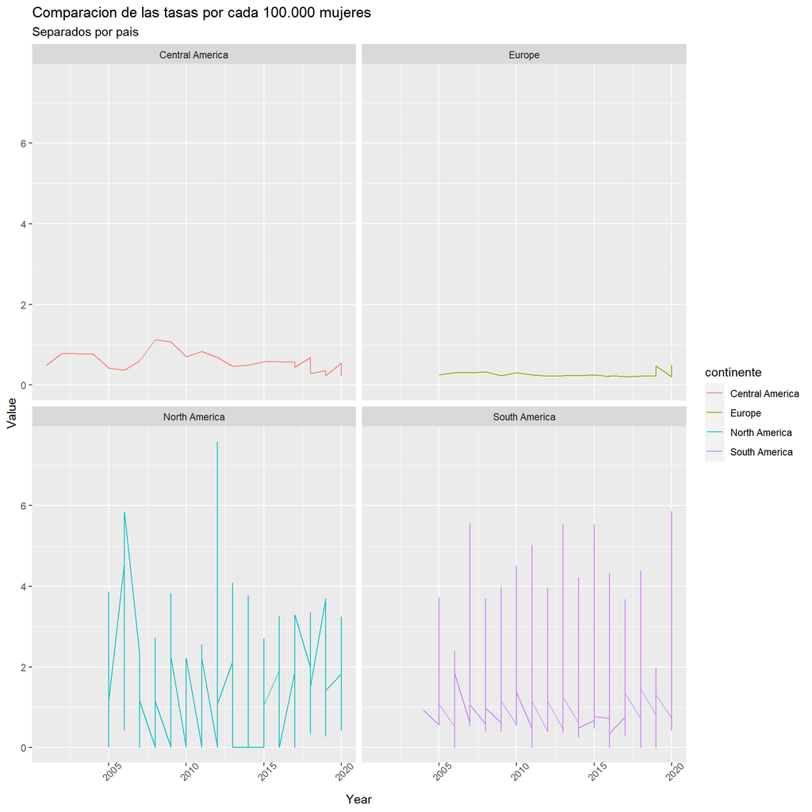

```r
grafico1
```

#### Gráfico 2. TASA DE MUERTES POR CADA 100.000 MUJERES CONSIDERANDO SI EXISTEN O NO LEGISLACIONES QUE REGULEN ESTE TIPO DE CRIMEN.

Tomando en cuenta estos datos únicamente, se hizo uso de un gráficos de barras, de donde se puede ver representado dos barras por país, en donde una de ellas representa la tasa antes del decreto de la legislación y la otra representa la tasa luego de la aplicación de la legislación.

```r
new_data <- left_join(data4,data5,by=c("Entity","Year"))

women_grouped <- new_data %>%
  filter(!is.na(HasLegislationDomesticViolence), Entity %in% c("Chile", "Dominica", "Panamá", "Suriname")) %>%
  group_by(Entity, HasLegislationDomesticViolence) %>%
  summarize(mean_death_rate = mean(Death))
```

```r
grafico2 <- ggplot(women_grouped, aes(x = Entity, y = mean_death_rate, fill = factor(HasLegislationDomesticViolence))) +
  geom_bar(stat = "identity", position = "dodge") +
  theme(axis.text.x = element_text(angle = 45)) +
  labs(title = "Comparacion de Tasas de Muerte promedio antes y despues de legislaciones",
       x = "Pais",
       y = "Tasa de Muerte Promedio",
       fill = "Status de Legislacion") +
  theme(plot.title = element_text(hjust = 0.5))

knitr::opts_chunk$set(fig.width = 15, fig.height = 10)
```

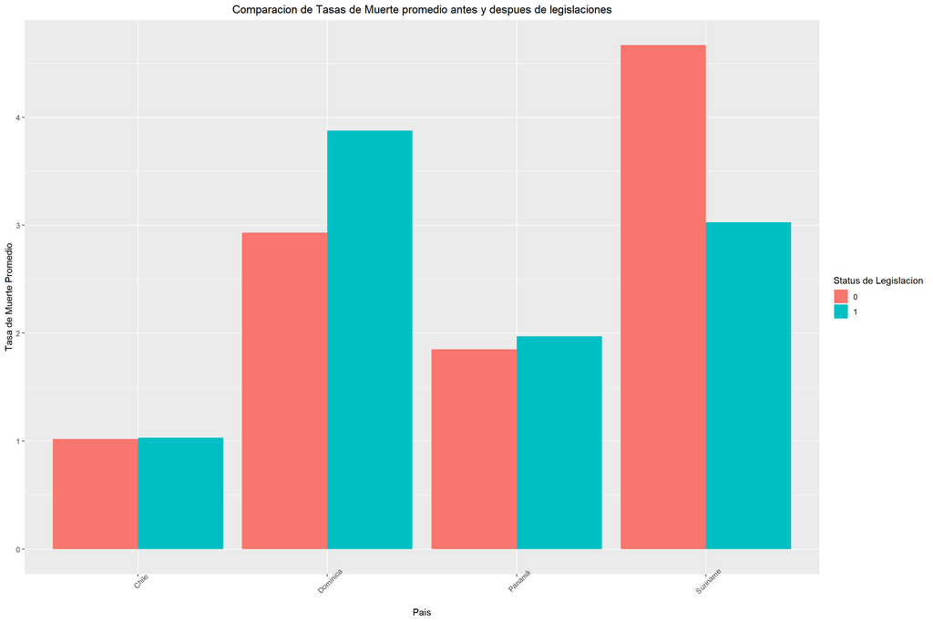

```r
grafico2
```

Inicialmente se puede observar que, para los datos obtenidos, los países que no poseían legislaciones relacionadas a estos crímenes, pero si se registraban actos de violencia de esta índole. Por otro lado, se puede apreciar que la mayoría de países tienen algún tipo de legislación que regula estos crímenes, inclusive los que en la primera gráfica tienen data registrada, es decir, que en un inicio no tenían.

#### Gráfico 3. CANTIDAD DE MUERTES MOTIVADO POR LA VIOLENCIA DE GÉNERO SEPARADO POR PAÍS.

La idea de este gráfico es mostrar de forma más explicita la cantidad de muertes por violencia de género que han ido ocurriendo a lo largo del tiempo dentro de cada región. Más específicamente desde el año 2000 hasta el 2020 por cada región que se encuentra participando en este estudio. Para esto también se empleó un gráfico de líneas de donde se han separado por región.

```r
colors_vec <- c("#4d4dff", "#00b3b3", "#00cc99", "#b3b300", "#b35900", "#cc99cc", "#ff4d4d", "#808080", "#ff9933", "#6666ff", "#00e6e6", "#b3b3b3", "#ff66ff", "#ffcc99", "#99ff99", "#ff6666", "#b3b300", "#00b3b3", "#ff99cc", "#6666ff", "#ffcc00", "#cc00cc", "#ff4d4d", "#00cc00", "#b35900", "#4d4dff", "#808080", "#FF9933", "#99E6E6", "#FF99CC", "#6666FF", "#FFCC70", "#CC00CC")
names(colors_vec) <- c("Costa Rica", "Trinidad y Tabago", "San Vicente y las Granadinas", "Colombia", "España", "Granada", "Jamaica", "Nicaragua", "Puerto Rico", "República Dominicana", "Santa Lucía", "Suriname", "Dominica", "Saint Kitts y Nevis", "Islas Vírgenes Británicas", "Anguila", "Antigua y Barbuda", "Guyana", "Montserrat", "Chile", "Paraguay", "Uruguay", "Perú", "Honduras", "Barbados", "Belice", "El Salvador", "Argentina", "Venezuela (República Bolivariana de)", "Ecuador", "Portugal", "Cuba", "Panamá")


grafico3 = data %>%
  filter(Tipodevalor == 'Número absoluto') %>%
  ggplot(aes( x= Year, y= Value, color=continente)) +
  geom_line() +
  theme(axis.text.x = element_text(angle = 45)) +
  ggtitle("Comparacion de las muertes de Mujeres", "Separados por pais") +
  facet_wrap(~continente)

knitr::opts_chunk$set(fig.width=10, fig.height=10)
```

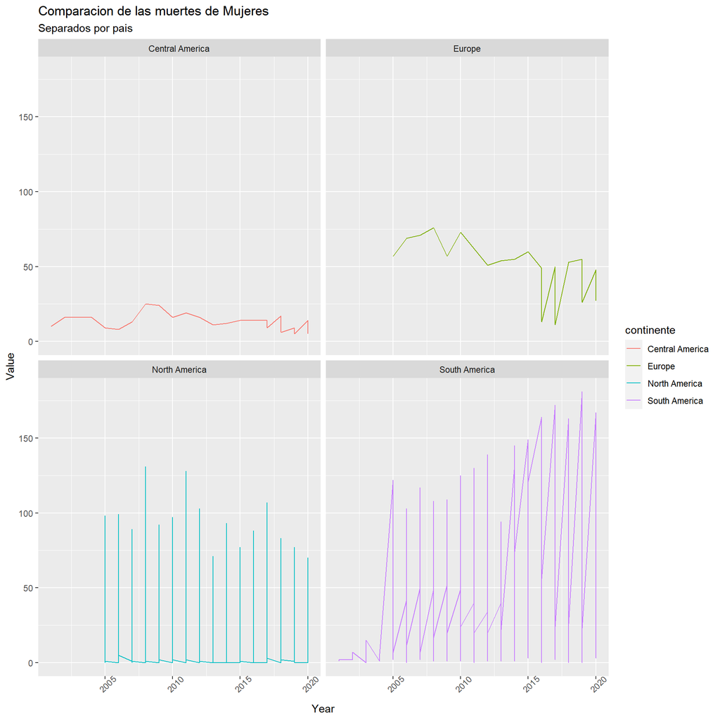

```r
grafico3
```

El número de muertes de mujeres por violencia de género en muchos paises va aumentando, o mantienen cierta estabilidad, es decir, suben o bajan muy poco. Es interesante destacar que algunos países con altos números de muertes de mujeres ocasioandas por la violencia de género pueden tener tasas relativamente bajas de muertes por cada 100.000 habitantes debido a su población femenina más grande. Sin embargo, esto no significa que la violencia de género sea menos prevalente o menos grave en estos países.

### CONCLUSIÓN.

La violencia de género es un problema sistémico que se basa en la dinámica del poder de género, y esto se refleja con la información recopilada para este estudio. Las legislaciones, leyes y políticas por sí solas, a nivel general no forman resultados de manera significativa con respecto a un cambio en el comportamiento, un cambio normativo o incluso una aplicación efectiva en cada país de las regiones estudiadas. Las legislaciones que protegen a las personas vulnerables que ya se encuentran aplicadas, a menudo perpetúan la violencia de género sistémica en las sociedades y actúan como una barrera para la reparación legal de las mujeres y adolescentes. Observando los países de América Latina, El Caribe, España y Portugal, la violencia de genero sigue siendo sensible, oculta y estigmatizada. En todos estos países, las mujeres y las adolescentes no buscan reparación legal debido a una variedad de factores, incluido el miedo a las represalias, la vergüenza y el miedo a la estigmatización, y la dependencia económica. Además, la violencia de genero afecta de forma desproporcionada a los países y regiones de ingresos bajos y medios bajos, para esto es necesario un estudio más complejo de como estas variables afectan en si el comportamiento de la sociedad y sus efectos.